# Uncertainty: (how to) deal with it

Peter Ralph

1 October 2020 – Advanced Biological Statistics

# Course overview

a box of tools

## Steps in data analysis

1. Care, or at least think, about the data.
2. Look at the data.
3. Query the data.
4. Check the results.
5. Communicate.

Often “statistics” focuses on *querying*. Doing that effectively requires all the other steps, too.

## Prerequisites

We’ll be assuming that you have some familiarity with

- programming, and
- statistics

For instance, you should be able to figure out what this means:

```r
x = c(2, 4, 3, 6)
y = c(5, 12, 4, 10, 2)
t.test(x, y)
```

```
##
##  Welch Two Sample t-test
##
## data:  x and y
## t = -1.3761, df = 5.4988, p-value = 0.2222
## alternative hypothesis: true difference in means is not equal to 0
## 95 percent confidence interval:
##  -8.031728  2.331728
## sample estimates:
## mean of x mean of y
##      3.75      6.60
```

## Overview and mechanics

See [the course website](https://UO-Biostats.github.io/UO_ABS).

# Break

Please take 10 minutes to

1. answer the “Welcome Survey” on Canvas,
2. [get the course repository from github](https://uo-biostats.github.io/UO_ABS/pages/using-git.html),
3. [install Rstudio](https://rstudio.com/products/rstudio/download/) and/or
4. move around.

Questions?

# Some core statistical concepts

## Statistics or parameters?

**A **statistic** is**

a numerical description of a dataset.

**A **parameter** is**

a numerical attribute of a model of reality.

Often, *statistics* are used to estimate *parameters*.

## The two heads of classical statistics

estimating parameters, with uncertainty *(confidence intervals)*

evaluating (in-)consistency with a particular situation *($p$-values)*

1. What do these data tell us about the world?
2. How strongly do we believe it?

*This week:* digging in, with simple examples.

## Lurking, behind everything:

is *uncertainty*

thanks to *randomness*.

How do we understand randomness, concretely and quantitatively?

With *models*.

# A quick look at some data

## Some data

AirBnB hosts in Portland, OR: [website](http://insideairbnb.com/get-the-data.html) and [download link](http://data.insideairbnb.com/united-states/or/portland/2019-07-10/data/listings.csv.gz).

```r
airbnb <- read.csv("../Datasets/portland-airbnb-listings.csv")
nrow(airbnb)
```

```
## [1] 5634
```

```r
names(airbnb)
```

```
##   [1] "id"                                           "listing_url"                                  "scrape_id"                                    "last_scraped"
##   [5] "name"                                         "summary"                                      "space"                                        "description"
##   [9] "experiences_offered"                          "neighborhood_overview"                        "notes"                                        "transit"
##  [13] "access"                                       "interaction"                                  "house_rules"                                  "thumbnail_url"
##  [17] "medium_url"                                   "picture_url"                                  "xl_picture_url"                               "host_id"
##  [21] "host_url"                                     "host_name"                                    "host_since"                                   "host_location"
##  [25] "host_about"                                   "host_response_time"                           "host_response_rate"                           "host_acceptance_rate"
##  [29] "host_is_superhost"                            "host_thumbnail_url"                           "host_picture_url"                             "host_neighbourhood"
##  [33] "host_listings_count"                          "host_total_listings_count"                    "host_verifications"                           "host_has_profile_pic"
##  [37] "host_identity_verified"                       "street"                                       "neighbourhood"                                "neighbourhood_cleansed"
##  [41] "neighbourhood_group_cleansed"                 "city"                                         "state"                                        "zipcode"
##  [45] "market"                                       "smart_location"                               "country_code"                                 "country"
##  [49] "latitude"                                     "longitude"                                    "is_location_exact"                            "property_type"
##  [53] "room_type"                                    "accommodates"                                 "bathrooms"                                    "bedrooms"
##  [57] "beds"                                         "bed_type"                                     "amenities"                                    "square_feet"
##  [61] "price"                                        "weekly_price"                                 "monthly_price"                                "security_deposit"
##  [65] "cleaning_fee"                                 "guests_included"                              "extra_people"                                 "minimum_nights"
##  [69] "maximum_nights"                               "minimum_minimum_nights"                       "maximum_minimum_nights"                       "minimum_maximum_nights"
##  [73] "maximum_maximum_nights"                       "minimum_nights_avg_ntm"                       "maximum_nights_avg_ntm"                       "calendar_updated"
##  [77] "has_availability"                             "availability_30"                              "availability_60"                              "availability_90"
##  [81] "availability_365"                             "calendar_last_scraped"                        "number_of_reviews"                            "number_of_reviews_ltm"
##  [85] "first_review"                                 "last_review"                                  "review_scores_rating"                         "review_scores_accuracy"
##  [89] "review_scores_cleanliness"                    "review_scores_checkin"                        "review_scores_communication"                  "review_scores_location"
##  [93] "review_scores_value"                          "requires_license"                             "license"                                      "jurisdiction_names"
##  [97] "instant_bookable"                             "is_business_travel_ready"                     "cancellation_policy"                          "require_guest_profile_picture"
## [101] "require_guest_phone_verification"             "calculated_host_listings_count"               "calculated_host_listings_count_entire_homes"  "calculated_host_listings_count_private_rooms"
## [105] "calculated_host_listings_count_shared_rooms"  "reviews_per_month"
```

Questions: how much does an AirBnB typically cost in Portland? Do “instant bookable” ones cost more?

## Second, look at the data

```r
summary(airbnb$price)
```

```
##    $75.00   $100.00    $80.00   $125.00    $65.00    $95.00   $150.00    $85.00    $99.00    $60.00    $90.00   $120.00    $50.00    $70.00    $45.00    $55.00   $110.00   $200.00   $199.00    $89.00    $79.00
##       256       240       177       174       168       166       162       159       145       144       134       129       129       120       105        99        86        74        67        67        66
##   $115.00   $300.00    $40.00   $175.00    $59.00    $35.00   $135.00    $69.00   $250.00   $180.00   $130.00   $149.00   $105.00   $119.00   $140.00    $49.00    $68.00   $109.00   $145.00   $225.00    $72.00
##        65        65        64        63        60        59        56        56        51        50        49        48        46        43        40        40        37        34        34        33        33
##   $160.00    $78.00   $215.00    $82.00    $88.00    $98.00   $129.00    $30.00   $195.00    $74.00   $350.00    $73.00   $165.00    $36.00    $48.00    $71.00   $159.00   $169.00    $39.00    $58.00    $87.00
##        31        31        30        30        30        29        28        28        26        26        25        23        21        21        21        21        20        20        20        20        20
##   $400.00    $52.00    $64.00    $83.00   $999.00    $42.00    $54.00    $92.00 $1,023.00   $108.00   $275.00    $33.00    $43.00   $155.00   $179.00   $209.00    $44.00    $47.00    $77.00    $94.00    $97.00
##        19        19        19        19        19        18        18        18        17        17        17        17        17        16        16        16        16        16        16        16        16
##   $185.00    $38.00    $62.00    $67.00    $41.00    $84.00    $37.00   $375.00    $57.00   $128.00    $32.00   $139.00   $325.00    $34.00    $91.00   (Other)
##        15        15        15        15        14        14        13        13        13        12        12        11        11        11        11       663
```

```r
summary(airbnb$instant_bookable)
```

```
##    f    t
## 2960 2674
```

## Whoops

```r
airbnb$price <- as.numeric(gsub("$", "", airbnb$price, fixed=TRUE))
airbnb$instant_bookable <- (airbnb$instant_bookable == "t")
```

```r
summary(airbnb$price)
```

```
##    Min. 1st Qu.  Median    Mean 3rd Qu.    Max.    NA's
##     0.0    69.0    95.0   119.5   136.0   999.0      32
```

```r
summary(airbnb$instant_bookable)
```

```
##    Mode   FALSE    TRUE
## logical    2960    2674
```

```r
table(airbnb$bed_type) # hm
```

```
##
##        Airbed         Couch         Futon Pull-out Sofa      Real Bed
##             9             7            42            21          5555
```

## How much is a typical night?

```r
mean(airbnb$price, na.rm=TRUE)
```

```
## [1] 119.5396
```

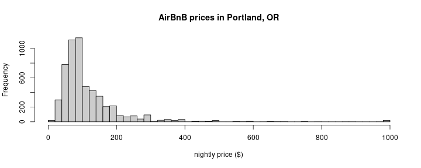

```r
hist(airbnb$price, breaks=40, xlab='nightly price ($)', col=grey(.8), xlim=range(airbnb$price, finite=TRUE), main='AirBnB prices in Portland, OR')
```

Conclusion?

## Do “instant bookable” charge more?

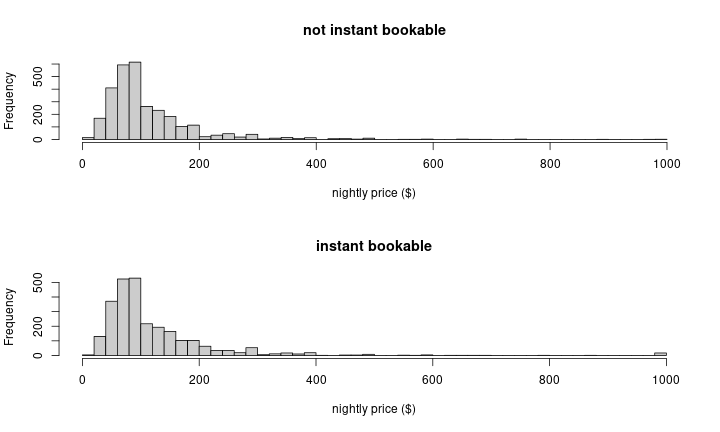

```r
layout(1:2)
instant <- airbnb$price[airbnb$instant_bookable]
not_instant <- airbnb$price[!airbnb$instant_bookable]
hist(not_instant, breaks=40, xlab='nightly price ($)', col=grey(.8), xlim=range(airbnb$price, finite=TRUE), main='not instant bookable')
hist(instant, breaks=40, xlab='nightly price ($)', col=grey(.8), main='instant bookable')
```

```r
(tt <- t.test(instant, not_instant))
```

```
##
##  Welch Two Sample t-test
##
## data:  instant and not_instant
## t = 3.6482, df = 5039.8, p-value = 0.0002667
## alternative hypothesis: true difference in means is not equal to 0
## 95 percent confidence interval:
##   4.475555 14.872518
## sample estimates:
## mean of x mean of y
##  124.6409  114.9668
```

## Conclusion

> Instant bookable hosts cost more than others (P=0.00027, t-test with df=5039.7695486).

*Critique this conclusion, and write your own.*

*Scribe:* person with the smallest `sample.int(1000, 1)`.

## Don’t forget Steps 1 and 5!

1. Care, or at least think, about the data.
2. Communicate.

How *big* is the difference? How sure are we?

Statistical significance does not imply real-world significance.

## Revised conclusion

So: what did we just do?

# Hypothesis testing and $p$-values

## A $p$-value is

> the probability of seeing a result at least as surprising as what was observed in the data, if the null hypothesis is true.

Usually, this means

- *a result* - numerical value of a statistic
- *surprising* - big
- *null hypothesis* - the model we use to calculate the $p$-value

which can all be defined to suit the situation.

## What does a small $p$-value mean?

*If* the null hypothesis *were* true, then you’d be really unlikely to see something like what you actually *did*.

So, either the “null hypothesis” is not a good description of reality or something surprising happened.

How useful this is depends on the null hypothesis.

## For instance

```
##
##  Welch Two Sample t-test
##
## data:  instant and not_instant
## t = 3.6482, df = 5039.8, p-value = 0.0002667
## alternative hypothesis: true difference in means is not equal to 0
## 95 percent confidence interval:
##   4.475555 14.872518
## sample estimates:
## mean of x mean of y
##  124.6409  114.9668
```

## Also for instance

```r
t.test(airbnb$price)
```

```
##
##  One Sample t-test
##
## data:  airbnb$price
## t = 91.32, df = 5601, p-value < 2.2e-16
## alternative hypothesis: true mean is not equal to 0
## 95 percent confidence interval:
##  116.9734 122.1058
## sample estimates:
## mean of x
##  119.5396
```

Is *that* $p$-value useful?

## Exercise:

*My hypothesis:* People tend to have longer index fingers on the hand they write with because writing stretches the ligaments.

*(class survey)* How many people have a longer index finger on the hand they write with?

*(class survey)* Everyone flip a coin:

```
ifelse(runif(1) < 0.5, "H", "T")
```

and put the result in [this google doc](https://docs.google.com/document/d/1bHHyvVaxZXrnN55Hpwhv55u9nbYDEHdC3jHXB5uOB6I/edit).

We want to estimate the parameter

$$\begin{equation}
\theta = \P(\text{random person has writing finger longer}) ,
\end{equation}$$

and now we have a *fake dataset with $\theta = 1/2$*.

Let’s get some more data:

```
n <- 37 # class size
sum(ifelse(runif(1) < 1/2, "H", "T") == "H")
```

and put the result in [the same google doc](https://docs.google.com/document/d/1bHHyvVaxZXrnN55Hpwhv55u9nbYDEHdC3jHXB5uOB6I/edit).

Now we can estimate the $p$-value for the hypothesis that $\theta = 1/2$.

A faster method:

```
replicate(1000, sum(rbinom(n, 1, 1/2) > 0))
```

or, equivalently,

```
rbinom(1000, n, 1/2)
```

## So, where do $p$-values come from?

Either math:

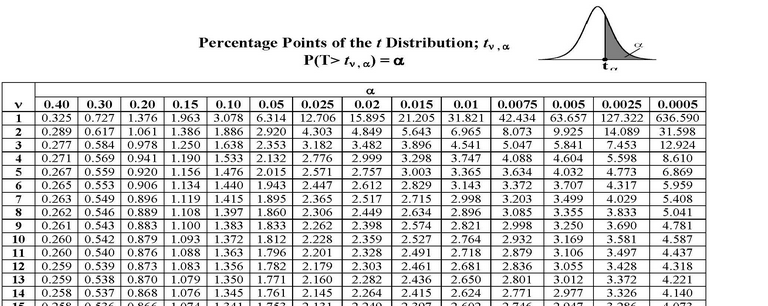

table of p-values from a t distribution

Or, computers. (maybe math, maybe simulation, maybe both)

So, where did *this* $p$-value come from?

```r
(tt <- t.test(instant, not_instant))
```

```
##
##  Welch Two Sample t-test
##
## data:  instant and not_instant
## t = 3.6482, df = 5039.8, p-value = 0.0002667
## alternative hypothesis: true difference in means is not equal to 0
## 95 percent confidence interval:
##   4.475555 14.872518
## sample estimates:
## mean of x mean of y
##  124.6409  114.9668
```

# Stochastic minute: the $t$ distribution

## The $t$ statistic

The $t$ statistic computed from a collection of $n$ numbers is the sample mean divided by the estimated standard error of the mean, which is the sample SD divided by $\sqrt{n}$.

If $x_1, \ldots, x_n$ are numbers, then
$$\begin{aligned}
\text{(sample mean)} \qquad \bar x &= \frac{1}{n}\sum_{i=1}^n x_i \\
\text{(sample SD)} \qquad s &= \sqrt{\frac{1}{n-1}\sum_{i=1}^n (x_i - \bar x)^2}
\end{aligned}$$
so
$$\begin{equation}
t(x) = \frac{\bar x}{s / \sqrt{n}} .
\end{equation}$$

## Consistency check

```r
n <- 20
x <- rnorm(n)
c(t.test(x)$statistic,
  mean(x) / (sd(x) / sqrt(n)))
```

```
##        t
## 1.318919 1.318919
```

## A demonstration

lots of times, and looking at the distribution of those $t$ scores.

Claim: no matter${}^*$ the distribution we sample from, the *sampling distribution* of the $t$ statistics should look close to the $t$ distribution.

## One sample

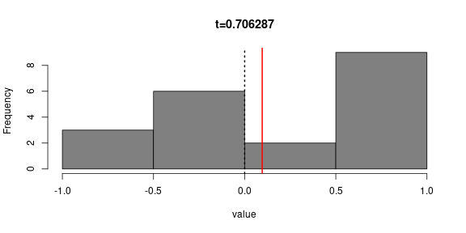

```r
n <- 20
x <- 2 * runif(n) - 1
hist(x, xlab='value', col=grey(0.5),
     main=sprintf("t=%f", mean(x)*sqrt(n)/sd(x)))
abline(v=0, lwd=2, lty=3)
abline(v=mean(x), col='red', lwd=2)
```

## More samples

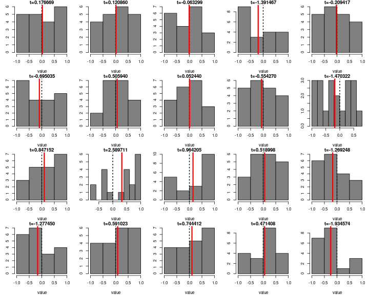

## Distribution of 1,000 sample $t$ scores

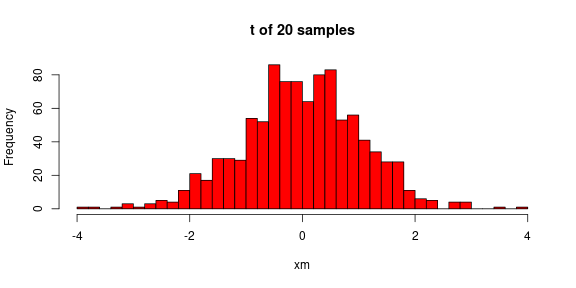

```r
xm <- replicate(1000, {
            x <- 2 * runif(n) - 1;
            mean(x) * sqrt(n) / sd(x) })
xh <- hist(xm, breaks=40, main=sprintf('t of %d samples', n), col='red')
```

## Distribution of 1,000 sample $t$ scores

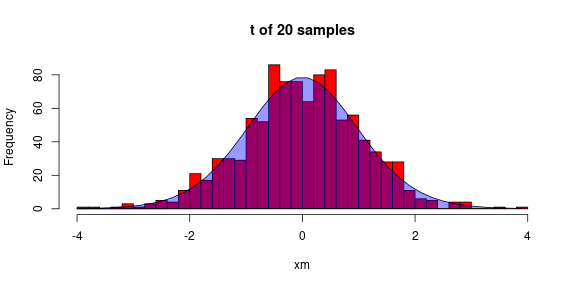

```r
plot(xh, main=sprintf('t of %d samples', n), col='red')
xx <- xh$breaks
polygon(c(xx[-1] - diff(xx)/2, xx[1]),
        c(length(xm)* diff(pt(xx, df=(n-1))), 0),
        col=adjustcolor("blue", 0.4))
```

## Exercise:

Do this again (use my code) except using

```
x <- rexp(n) - 1
```

instead of `2 * runif(n) - 1`.

# $p$s from $t$s

## In words:

The number of *standard errors* that the *sample mean* is away from the *true mean* has a $t$ distribution.

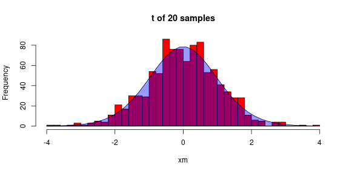

# Confident in confidence intervals?

```r
tt
```

```
##
##  Welch Two Sample t-test
##
## data:  instant and not_instant
## t = 3.6482, df = 5039.8, p-value = 0.0002667
## alternative hypothesis: true difference in means is not equal to 0
## 95 percent confidence interval:
##   4.475555 14.872518
## sample estimates:
## mean of x mean of y
##  124.6409  114.9668
```

## Confidence intervals

A *95% confidence interval* for an estimate is constructed so that no matter what the true value, the confidence interval overlaps the truth 95% of the time.

In other words, if we collect 1,000 independent samples from a population with true mean $\mu$, and construct confidence intervals for the mean from each, then about 950 of these should overlap $\mu$.

## How’s that work?

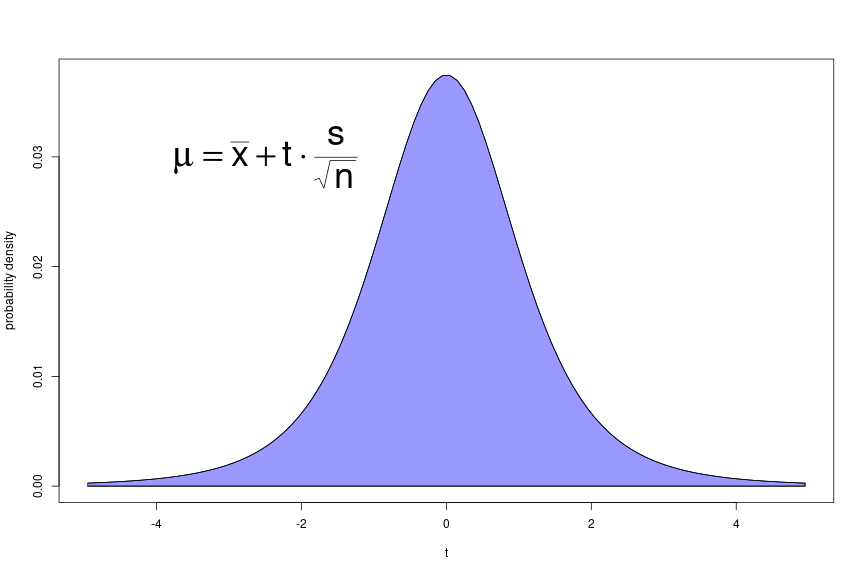

## How’s that work?

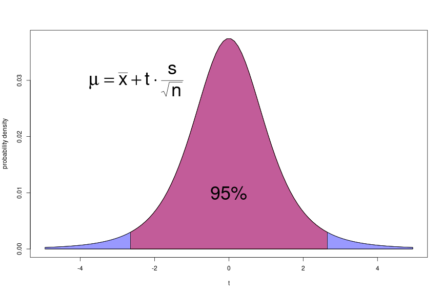

## Check this.

> if we collect 1,000 independent samples from a population with true mean $\mu$, and construct confidence intervals from each, then about 950 of these should overlap $\mu$.

Let’s take independent samples of size $n=20$ from a Normal distribution with $\mu = 0$. Example:

```r
n <- 20; mu <- 0
t.test(rnorm(n, mean=mu))$conf.int
```

```
## [1] -0.5259054  0.3753652
## attr(,"conf.level")
## [1] 0.95
```

```r
tci <- replicate(300, t.test(rnorm(n, mean=mu))$conf.int)
mean(tci[1,] > 0 | tci[2,] < 0)
```

```
## [1] 0.05666667
```

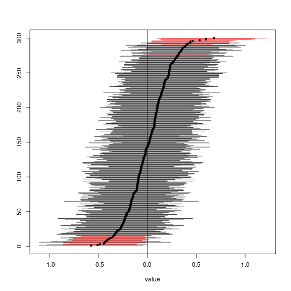

# Power analysis

## Group exercise

How does the margin of error change with sample size? By taking random samples from the `price` column of the `airbnb` data, make two plots:

1. Probability that a sample of size `n` of Portland AirBnB rooms has a sample mean within $10 of the (true) mean price of *all* rooms, as a function of `n`.
2. Expected difference between the mean price of a random sample of `n` Portland AirBnB rooms and the (true) mean price of *all* rooms, as a function of `n`.

## In class

# Stochastic minute: the Central Limit Theorem and the Normal distribution

## The CLT

The [Central Limit Theorem](https://en.wikipedia.org/wiki/Central_limit_theorem) says, roughly, that net effect of the *sum* of a bunch of small, *independent* random things can be well-approximated by a [Gaussian distribution](https://en.wikipedia.org/wiki/Normal_distribution), almost regardless of the details.

For instance: say $X_1, X_2, \ldots, X_n$ are independent, random draws with mean $\mu$ and standard deviation $\sigma$.

Then, the difference between the “true” mean, $\mu$, and the sample mean is Gaussian,
$$\begin{aligned}
\bar x = \frac{1}{n}\sum_{i=1}^n X_i \approx \Normal\left(\mu, \frac{\sigma}{\sqrt{n}}\right) .
\end{aligned}$$

## The Gaussian distribution

Also called the *Normal distribution*: see previous slide.

Saying that a random number $Z$ “is Normal”:
$$\begin{equation}
Z \sim \Normal(\mu, \sigma)
\end{equation}$$
means that
$$\begin{equation}
\P\left\{Z \ge \frac{x - \mu}{\sigma}\right\} = \int_x^\infty \frac{1}{\sqrt{2 \pi}} e^{-u^2/2} du .
\end{equation}$$

What to remember:

1. $Z$ is probably no more than a few times $\sigma$ away from $\mu$
2. Using R,

```
rnorm(10, mean=3, sd=2)    # random simulations
pnorm(5, mean=3, sd=2)     # probabilities
qnorm(0.975, mean=3, sd=2) # quantiles
```

## A demonstration

Let’s check this, by doing:

> find the sample mean of 100 random draws from some distribution

lots of times, and looking at the distribution of those sample means.

Claim: no matter the distribution we sample from, it should look close to Normal.

## One sample

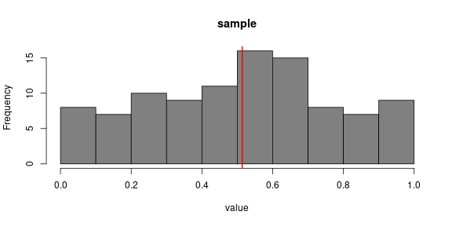

```r
n <- 100
x <- runif(n)
hist(x, xlab='value', main='sample', col=grey(0.5))
abline(v=mean(x), col='red', lwd=2)
```

## More samples

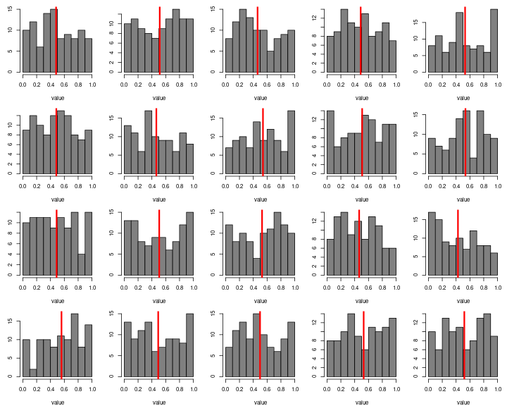

## Distribution of 1,000 sample means

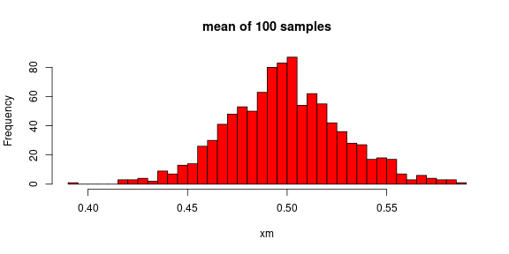

```r
xm <- replicate(1000, mean(runif(n)))
xh <- hist(xm, breaks=40, main=sprintf('mean of %d samples', n), col='red')
```

## Distribution of 1,000 sample means

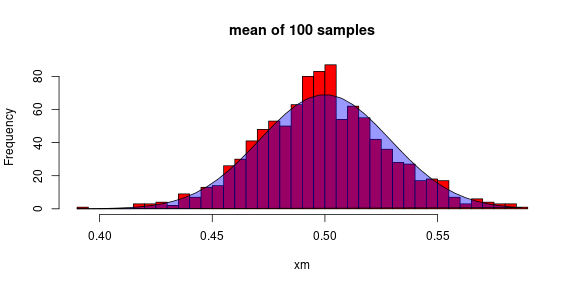

```r
plot(xh, main=sprintf('mean of %d samples', n), col='red')
xx <- xh$breaks
polygon(c(xx[-1] - diff(xx)/2, xx[1]),
        c(length(xm)* diff(pnorm(xx, mean=0.5, sd=1/sqrt(n*12))), 0),
        col=adjustcolor("blue", 0.4))
```

## Relationship to the $t$ distribution

If $Y$ and $Z_1, \ldots, Z_n$ are independent $\Normal(0, \sigma)$, and
$$\begin{equation}
X = \frac{Y}{ \sqrt{\frac{1}{n}\sum_{j=1}^n Z_j^2} }
\end{equation}$$
then
$$\begin{equation}
X \sim \StudentsT(n) .
\end{equation}$$

More usefully, *a sample mean divided by its standard error is$^*$ $t$ distributed.*

This is thanks to the Central Limit Theorem. ($^*$ usually, approximately)

# Recap